# EP06-avance2-equipo-08

2026-11-04

## Datos y librerias

Trabajamos con alfa = 0,05 para las seis preguntas

En todas las preguntas la variable respuesta es numerica, las observaciones se sortearon de las instancias disponibles y el analisis se limita a esas instancias

Si Shapiro entrega p menor a 0,05 tenemos evidencia contra normalidad, si p es mayor no significa que la normalidad quede demostrada

## Pregunta 1

“Considerando las instancias con 60 o más nodos, ¿hay diferencias entre las mejores soluciones que encuentran las versiones A y B del algoritmo cuando resuelven las mismas instancias? Con la semilla 680, saquen 20 instancias y usen sus resultados con las dos versiones. Si sacaron bien la muestra, deberían obtener: n = 20; A, media 97,952; B, media 94,766 [% del óptimo].”

Con semilla 680 se sacan 20 instancias y se usan las dos versiones para cada una

Prueba A Ocupar:

t de Student para muestras pareadas, porque las dos versiones se prueban con las mismas instancias

Hipotesis de la prueba parametrica:

H0 = La media de las diferencias A menos B es igual a cero

HA = La media de las diferencias A menos B es distinta de cero

Condiciones:

1. Escala = La calidad esta medida como porcentaje del optimo
2. Independencia = Cada instancia seleccionada es distinta de las demas, aunq las dos mediciones dentro de cada instancia estan pareadas
3. Normalidad = Lo importante es revisar la normalidad de las difernecias entre A y B, no la normalidad de cada version por separado

```r
# Pregunta 1: considerando instancias con 60 o mas nodos, hay diferencias entre las mejores soluciones de A y B al resolver las mismas instancias
# Con semilla 680 sacamos 20 instancias para las dos versiones
# Control: n = 20, A media 97,952 y B media 94,766 en porcentaje del optimo
# Filtramos antes de fijar la semilla y de hacer sample
base_1 <- datos_xd |>
  filter(n.nodos >= 60)

set.seed(680)
filas_1 <- sample(seq_len(nrow(base_1)), size = 20)

muestra_1 <- base_1 |>
  slice(filas_1)

# Pasamos a formato largo para comparar las dos versiones
largo_1 <- muestra_1 |>
  select(instancia, mejor.A, mejor.B) |>
  pivot_longer(
    cols = starts_with("mejor."),
    names_to = "version",
    values_to = "valor"
  ) |>
  mutate(version = sub("mejor.", "", version, fixed = TRUE))

resumen(largo_1) |>
  knitr::kable(digits = 3)
```

| version | n | media | mediana | desviacion |
| --- | --- | --- | --- | --- |
| A | 20 | 97.952 | 98.335 | 1.252 |
| B | 20 | 94.766 | 96.260 | 4.608 |

Si la muesra esta bien, las medias quedan cerca de 97,952 para A y 94,766 para B

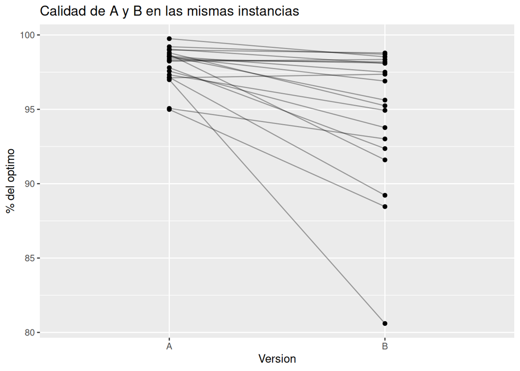

```r
# Vemos las dos mediciones de cada instancia y sus distribuciones
largo_1 |>
  ggplot(aes(x = version, y = valor, group = instancia)) +
  geom_line(alpha = 0.35) +
  geom_point() +
  labs(title = "Calidad de A y B en las mismas instancias", x = "Version", y = "% del optimo")
```

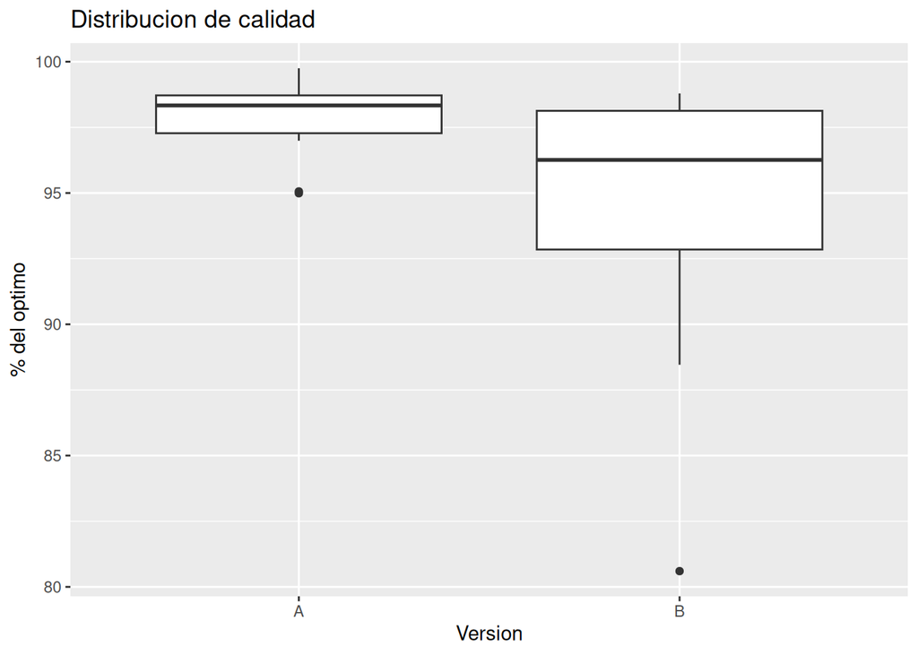

```r
largo_1 |>
  ggplot(aes(x = version, y = valor)) +
  geom_boxplot() +
  labs(title = "Distribucion de calidad", x = "Version", y = "% del optimo")
```

```r
# Restamos por instancia, asi se revisa lo que pide la prueba pareada
dif_1 <- muestra_1 |>
  transmute(diferencia = mejor.A - mejor.B)

shapiro.test(dif_1$diferencia)
```

```
##
##  Shapiro-Wilk normality test
##
## data:  dif_1$diferencia
## W = 0.7748, p-value = 0.0003724
```

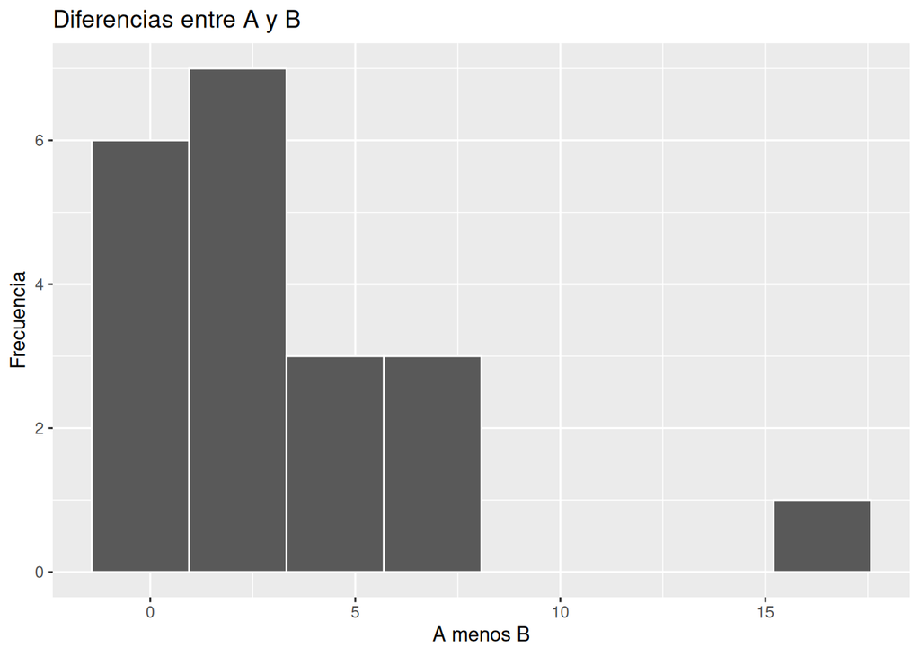

```r
dif_1 |>
  ggplot(aes(x = diferencia)) +
  geom_histogram(bins = 8, color = "white") +
  labs(title = "Diferencias entre A y B", x = "A menos B", y = "Frecuencia")
```

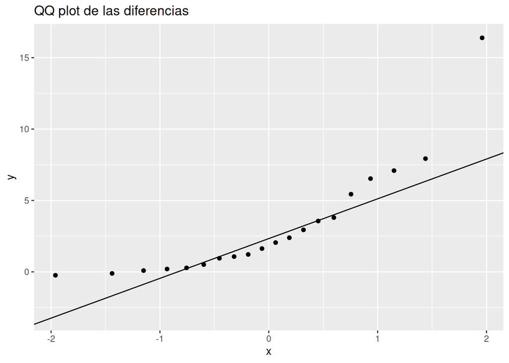

```r
dif_1 |>
  ggplot(aes(sample = diferencia)) +
  stat_qq() +
  stat_qq_line() +
  labs(title = "QQ plot de las diferencias")
```

La normalidad de las diferencias no se cumple bien, ya que el p de Shapiro es menor a 0,05 y el grafico muestra asimetria

Prueba basada en rangos:

Wilcoxon de rangos con signo para datos pareados

H0 = La distribucion de las diferencias pareadas esta centrada de forma simetrica en cero

HA = Hay un desplazamiento distinto de cero en las diferencias pareadas

La prueba no necesita normalidad, pero para hablar directamente de la mediana de las diferencias necesitamos que estas sean razonablemente simetricas

```r
# Aplicamos Wilcoxon pareado, sin ocupar la prueba t
prueba_1 <- wilcox.test(
  muestra_1$mejor.A,
  muestra_1$mejor.B,
  paired = TRUE,
  exact = FALSE,
  correct = FALSE
)

prueba_1
```

```
##
##  Wilcoxon signed rank test
##
## data:  muestra_1$mejor.A and muestra_1$mejor.B
## V = 204, p-value = 0.0002191
## alternative hypothesis: true location shift is not equal to 0
```

Respuesta:

Como el p de Wilcoxon es 2.19^{-4} y es menor a 0,05, rechazamos H0 y encontramos evidencia de diferencias entre A y B al resolver las mismas instancias

En la muesra A consigue porcentajes mas altos del optimo, aunque la asimetria de las diferencias nos obliga a ser cuidadosos al interpretar el resultado como diferencia de medianas

## Pregunta 2

“Considerando las instancias con 60 o más nodos, ¿hay diferencias entre las mejores soluciones que encuentran las versiones A, B y C del algoritmo cuando resuelven las mismas instancias? Con la semilla 558, saquen 21 instancias y usen sus resultados con las tres versiones. Si sacaron bien la muestra, deberían obtener: n = 21; A, media 97,494; B, media 95,437; C, media 96,178 [% del óptimo].”

Con semilla 558 se sacan 21 instancias y se ocupan los resultados de las tres versiones

Prueba A Ocupar:

ANOVA de medidas repetidas, ya que cada instancia se utiliza para evaluar A, B y C

Con prodecimiento post hoc de comparaciones multiples cuando haga falta

Hipotesis de la prueba parametrica:

H0 = Las medias de calidad son iguales en A, B y C

HA = Al menos una de las medias es distinta

Condiciones:

1. Escala = Los porcentajes son variables numericas
2. Independencia = Las instancias son distintas entre si, pero dentro de cada instancia hay tres mediciones relacionadas
3. Normalidad = Revisamos las diferencias por pares y sus QQ plots
4. Esfericidad = Para el ANOVA se necesita que las varianzas de las diferencias entre pares sean similares, revisamos esto de forma preliminar sin aplicar ANOVA

```r
# Pregunta 2: considerando instancias con 60 o mas nodos, hay diferencias entre las mejores soluciones de A, B y C en las mismas instancias
# Con semilla 558 sacamos 21 instancias para las tres versiones
# Control: n = 21, A media 97,494, B media 95,437 y C media 96,178 en porcentaje del optimo
# Sorteamos una sola vez para mantener el pareo
base_2 <- datos_xd |>
  filter(n.nodos >= 60)

set.seed(558)
filas_2 <- sample(seq_len(nrow(base_2)), size = 21)

muestra_2 <- base_2 |>
  slice(filas_2)

largo_2 <- muestra_2 |>
  select(instancia, mejor.A, mejor.B, mejor.C) |>
  pivot_longer(
    cols = starts_with("mejor."),
    names_to = "version",
    values_to = "valor"
  ) |>
  mutate(version = sub("mejor.", "", version, fixed = TRUE))

resumen(largo_2) |>
  knitr::kable(digits = 3)
```

| version | n | media | mediana | desviacion |
| --- | --- | --- | --- | --- |
| A | 21 | 97.494 | 97.82 | 1.642 |
| B | 21 | 95.437 | 95.85 | 3.036 |
| C | 21 | 96.178 | 97.03 | 2.571 |

Las medias que deberiamos obtener son A = 97,494, B = 95,437 y C = 96,178

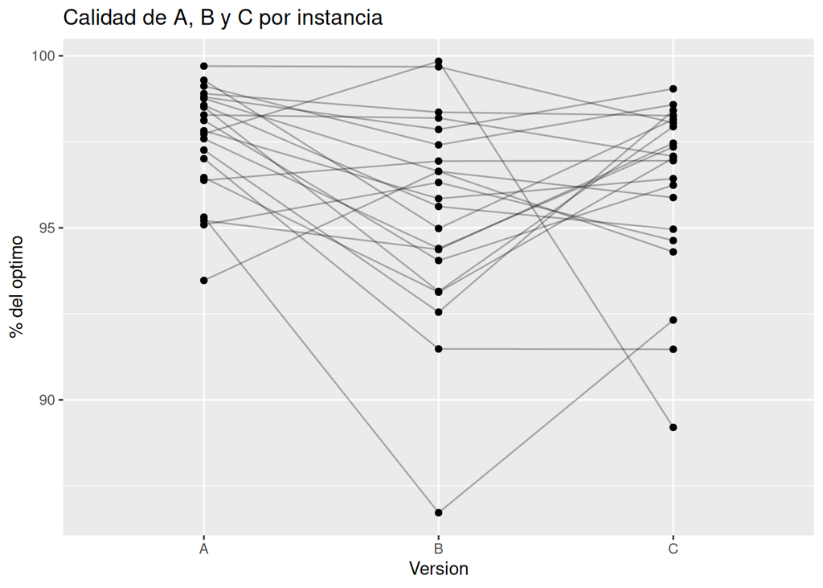

```r
# Grafico pareado y cajas para ver donde se concentran los valors
largo_2 |>
  ggplot(aes(x = version, y = valor, group = instancia)) +
  geom_line(alpha = 0.3) +
  geom_point() +
  labs(title = "Calidad de A, B y C por instancia", x = "Version", y = "% del optimo")
```

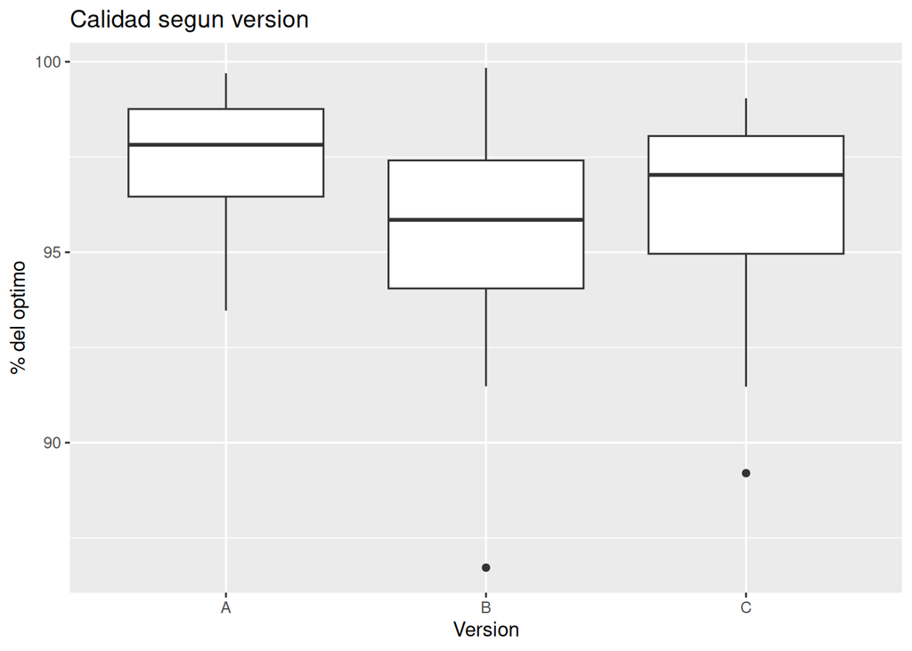

```r
largo_2 |>
  ggplot(aes(x = version, y = valor)) +
  geom_boxplot() +
  labs(title = "Calidad segun version", x = "Version", y = "% del optimo")
```

```r
# Comparamos las diferencias pareadas y sus varianzas
# Esto ayuda a revisar normalidad y esfericidad sin correr ANOVA
diferencias_2 <- tibble(
  `A-B` = muestra_2$mejor.A - muestra_2$mejor.B,
  `A-C` = muestra_2$mejor.A - muestra_2$mejor.C,
  `B-C` = muestra_2$mejor.B - muestra_2$mejor.C
) |>
  pivot_longer(everything(), names_to = "comparacion", values_to = "diferencia")

diferencias_2 |>
  group_by(comparacion) |>
  summarise(
    varianza = var(diferencia),
    W = unname(shapiro.test(diferencia)$statistic),
    p.valor = shapiro.test(diferencia)$p.value,
    .groups = "drop"
  ) |>
  knitr::kable(digits = 5)
```

| comparacion | varianza | W | p.valor |
| --- | --- | --- | --- |
| A-B | 8.05105 | 0.98910 | 0.99620 |
| A-C | 5.86363 | 0.88965 | 0.02216 |
| B-C | 12.74931 | 0.88176 | 0.01575 |

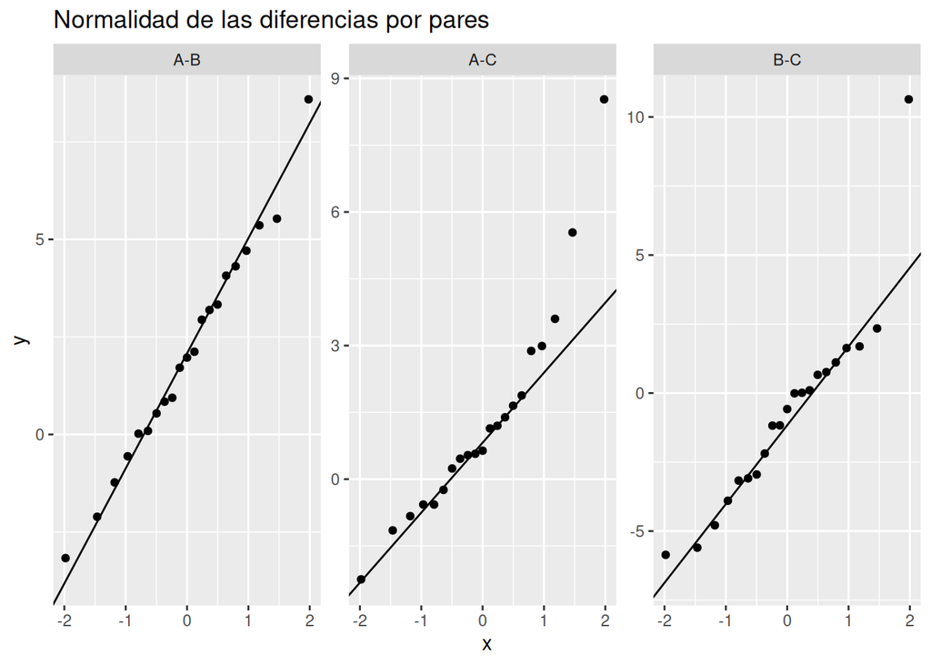

```r
# QQ plots de las diferencias, no de las medias
# Con esto tambien podemos observar si hay valores extremos
diferencias_2 |>
  ggplot(aes(sample = diferencia)) +
  stat_qq() +
  stat_qq_line() +
  facet_wrap(~ comparacion, scales = "free") +
  labs(title = "Normalidad de las diferencias por pares")
```

No todas las diferencias parecen normales, en especial las comparaciones que incluyen C, por lo que no conviene confiar de inmediato en el ANOVA

Las varianzas de las diferencias tampoco quedan exactamente iguales, pero esta comparacion es solo preliminar y no reemplaza un test formal de esfericidad

Prueba basada en rangos:

Friedman, porque son tres verisones evaluadas sobre las mismas instancias

H0 = Las tres versiones tienen la misma distribucion de rangos dentro de las instancias, sin que una tienda a quedar sistematicamente mas alta

HA = Al menos una version presenta rangos sistematicamente distintos

Post hoc = Wilcoxon pareado por cada par, ajustando los p con Holm

En cada comparacion post hoc H0 indica que las diferencias pareadas estan centradas de forma simetrica en cero y HA que no lo estan

```r
# Friedman es el procedimiento omnibus para las tres muestras relacionadas
prueba_2 <- friedman.test(
  as.matrix(muestra_2 |> select(mejor.A, mejor.B, mejor.C))
)

prueba_2
```

```
##
##  Friedman rank sum test
##
## data:  as.matrix(select(muestra_2, mejor.A, mejor.B, mejor.C))
## Friedman chi-squared = 9.2381, df = 2, p-value = 0.009862
```

```r
# Hacemos tres Wilcoxon pareados y corregimos por comparaciones multiples
pares_2 <- list(c("A", "B"), c("A", "C"), c("B", "C"))

post_2 <- lapply(pares_2, function(par) {
  x <- muestra_2[[paste0("mejor.", par[1])]]
  y <- muestra_2[[paste0("mejor.", par[2])]]
  tibble(
    comparacion = paste(par, collapse = " vs "),
    p.valor = wilcox.test(x, y, paired = TRUE, exact = FALSE, correct = FALSE)$p.value
  )
}) |>
  bind_rows() |>
  mutate(p.ajustado = p.adjust(p.valor, method = "holm"))

post_2 |>
  knitr::kable(digits = 5)
```

| comparacion | p.valor | p.ajustado |
| --- | --- | --- |
| A vs B | 0.00461 | 0.01384 |
| A vs C | 0.02174 | 0.04348 |
| B vs C | 0.18654 | 0.18654 |

Respuesta:

Friedman tiene p = 0.00986, menor a 0,05, asi que se rechaza H0 y hay evidencia de diferencias entre las tres versiones

Con Holm resultan significativas las comparaciones A con B y A con C, pero no B con C

En esta muesra A presenta mejor calidad que las otras dos, mientras entre B y C no encontramos evidencia suficiente de una diferencia

## Pregunta 3

“Considerando las instancias con 70 o más nodos, ¿hay diferencias entre los tiempos de ejecución de las versiones B y C del algoritmo? Con la semilla 287, saquen 24 instancias para la versión B y 23 instancias para la versión C, todas distintas (muestras independientes). Si sacaron bien la muestra, deberían obtener: B, n = 24 y media 1.989.544; C, n = 23 y media 1.156.347 [ms].”

Con semilla 287 se sacan 24 instancias para B y otras 23 distintas para C

Prueba A Ocupar:

t de Student para muestras independientes, preferiblemente la variante de Welch si las varianzas son distintas

Hipotesis de la prueba parametrica:

H0 = Los tiempos medios de B y C son iguales

HA = Los tiempos medios de B y C son distintos

Condiciones:

1. Escala = El tiempo es numerico continuo y se mide en ms
2. Independencia = Una instancia aparece solo en una de las dos muestras
3. Normalidad = Se revisa en cada grupo con Shapiro y QQ plots
4. Varianzas = Se comparan con Fligner, la t clasica necesita varianzas similares pero Welch no

```r
# Pregunta 3: considerando instancias con 70 o mas nodos, hay diferencias entre los tiempos de ejecucion de B y C
# Con semilla 287 sacamos 24 instancias para B y 23 para C, todas distintas
# Control: B media 1989544 y C media 1156347 ms
# Las primeras 24 filas sorteadas van para B y las otras 23 para C
base_3 <- datos_xd |>
  filter(n.nodos >= 70)

set.seed(287)
filas_3 <- sample(seq_len(nrow(base_3)), size = 47)

muestra_3 <- bind_rows(
  base_3 |> slice(filas_3[1:24]) |>
    transmute(instancia, version = "B", valor = tiempo.B),
  base_3 |> slice(filas_3[25:47]) |>
    transmute(instancia, version = "C", valor = tiempo.C)
)

# Confirmamos que ninguna instancia quedo repetida
stopifnot(n_distinct(muestra_3$instancia) == 47)

resumen(muestra_3) |>
  knitr::kable(digits = 1)
```

| version | n | media | mediana | desviacion |
| --- | --- | --- | --- | --- |
| B | 24 | 1989544 | 1858718 | 1009370.1 |
| C | 23 | 1156347 | 1017315 | 522635.6 |

Las medias de control son B = 1.989.544 y C = 1.156.347 ms

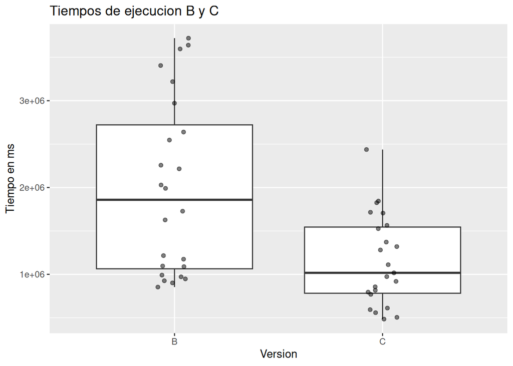

```r
# Cajas con puntos para ver dispersion y tiempos extremos
muestra_3 |>
  ggplot(aes(x = version, y = valor)) +
  geom_boxplot() +
  geom_jitter(width = 0.08, alpha = 0.5) +
  labs(title = "Tiempos de ejecucion B y C", x = "Version", y = "Tiempo en ms")
```

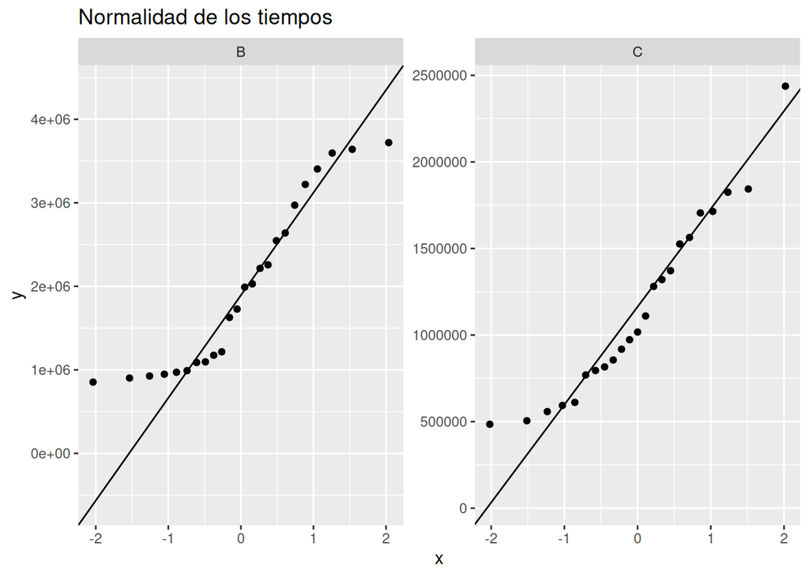

```r
# QQ plot separado por version
muestra_3 |>
  ggplot(aes(sample = valor)) +
  stat_qq() +
  stat_qq_line() +
  facet_wrap(~ version, scales = "free") +
  labs(title = "Normalidad de los tiempos")
```

```r
# Shapiro revisa normalidad y Fligner revisa dispersion
normalidad(muestra_3) |>
  knitr::kable(digits = 5)
```

| version | W | p.valor |
| --- | --- | --- |
| B | 0.88066 | 0.00857 |
| C | 0.93807 | 0.16333 |

```r
fligner.test(valor ~ version, data = muestra_3)
```

```
##
##  Fligner-Killeen test of homogeneity of variances
##
## data:  valor by version
## Fligner-Killeen:med chi-squared = 10.235, df = 1, p-value = 0.001378
```

B tiene p menor a 0,05 en Shapiro y Fligner tambien muestra evidencia de varianzas distintas

Por esto una t clasica no parece confiable con los datos originales, aunque Welch corriga el tema de las varianzas no arregla por si solo la asimetria

Prueba basada en rangos:

Wilcoxon de suma de rangos, tambien conocido como Mann Whitney, para dos grupos independietes

H0 = B y C tienen la misma distribucion de tiempos

HA = Las distribuciones de los tiempos de B y C son distintas

Si las formas fueran parecidas se podria hablar de diferencias de ubicacion, pero con distinta dispersion debemos ser mas cuidadosos

```r
# Wilcoxon para muestras independientes
prueba_3 <- wilcox.test(
  valor ~ version,
  data = muestra_3,
  exact = FALSE,
  correct = FALSE
)

prueba_3
```

```
##
##  Wilcoxon rank sum test
##
## data:  valor by version
## W = 418, p-value = 0.002511
## alternative hypothesis: true location shift is not equal to 0
```

Respuesta:

El p = 0.00251 es menor a 0,05, entonces se rechaza H0 y los tiempos de B y C muestran diferencias estadisticamente significativas

B tiene tiempos mas altos en la muesra, aunque por las distntas dispersiones no interpretamos esto simplemente como una prueba de medianas iguales

## Pregunta 4

“Considerando las instancias con 50 o más nodos, ¿hay diferencias entre los tiempos de ejecución de las versiones A y B del algoritmo? Con la semilla 558, saquen 16 instancias para la versión A y 17 instancias para la versión B, todas distintas (muestras independientes). Si sacaron bien la muestra, deberían obtener: A, n = 16 y media 1.114.799; B, n = 17 y media 1.727.082 [ms].”

Con semilla 558 se sacan 16 instancias para A y 17 para B, todas distintas

Prueba A Ocupar:

t de Student para muestras independientes, o Welch cuando no podemos asumir varianzas iguales

Hipotesis de la prueba parametrica:

H0 = Las medias de tiempo de A y B son iguales

HA = Las medias de tiempo de A y B son distintas

Condiciones:

1. Escala = El tiempo esta medido en ms
2. Independencia = Son instancias distintas en ambas muestras
3. Normalidad = Revisamos Shapiro y QQ plot en los dos grupos
4. Varianzas = Revisamos Fligner sin aplicar la t

```r
# Pregunta 4: considerando instancias con 50 o mas nodos, hay diferencias entre los tiempos de ejecucion de A y B
# Con semilla 558 sacamos 16 instancias para A y 17 para B, todas distintas
# Control: A media 1114799 y B media 1727082 ms
# Se sortean 33 instancias, 16 para A y 17 para B
base_4 <- datos_xd |>
  filter(n.nodos >= 50)

set.seed(558)
filas_4 <- sample(seq_len(nrow(base_4)), size = 33)

muestra_4 <- bind_rows(
  base_4 |> slice(filas_4[1:16]) |>
    transmute(instancia, version = "A", valor = tiempo.A),
  base_4 |> slice(filas_4[17:33]) |>
    transmute(instancia, version = "B", valor = tiempo.B)
)

# Confirmamos que ninguna instancia quedo repetida
stopifnot(n_distinct(muestra_4$instancia) == 33)

resumen(muestra_4) |>
  knitr::kable(digits = 1)
```

| version | n | media | mediana | desviacion |
| --- | --- | --- | --- | --- |
| A | 16 | 1114799 | 884691.5 | 956264.7 |
| B | 17 | 1727082 | 1366115.0 | 1085022.8 |

Las medias de control son A = 1.114.799 y B = 1.727.082 ms

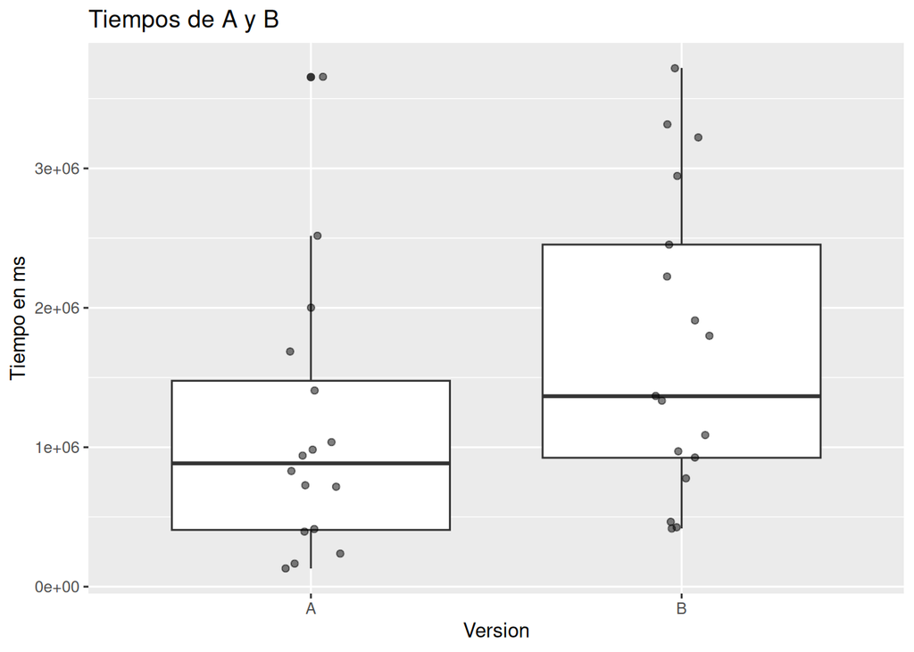

```r
# Miramos el boxplot y luego los cuantiles teoricos normales
muestra_4 |>
  ggplot(aes(x = version, y = valor)) +
  geom_boxplot() +
  geom_jitter(width = 0.08, alpha = 0.5) +
  labs(title = "Tiempos de A y B", x = "Version", y = "Tiempo en ms")
```

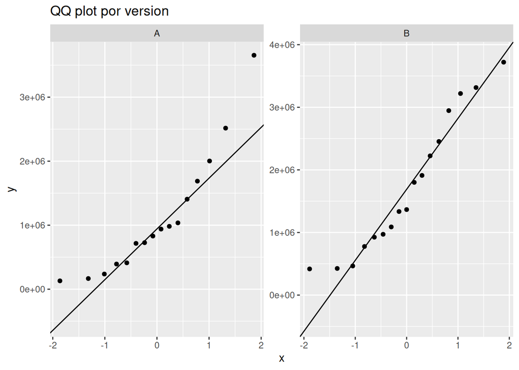

```r
muestra_4 |>
  ggplot(aes(sample = valor)) +
  stat_qq() +
  stat_qq_line() +
  facet_wrap(~ version, scales = "free") +
  labs(title = "QQ plot por version")
```

```r
# Revisamos normalidad y dispersion de las muestras
normalidad(muestra_4) |>
  knitr::kable(digits = 5)
```

| version | W | p.valor |
| --- | --- | --- |
| A | 0.86506 | 0.02287 |
| B | 0.92114 | 0.15435 |

```r
fligner.test(valor ~ version, data = muestra_4)
```

```
##
##  Fligner-Killeen test of homogeneity of variances
##
## data:  valor by version
## Fligner-Killeen:med chi-squared = 0.91975, df = 1, p-value = 0.3375
```

A no supera el chequeo de normalidad con Shapiro, por lo que usar la t en los datos originales es discutible

Prueba basada en rangos:

Wilcoxon de suma de rangos para muestras independientes

H0 = A y B tienen la misma distribucion de tiempos

HA = Las distribuciones de los tiempos son diferentes

```r
# Wilcoxon para comparar dos grupos sin parear
prueba_4 <- wilcox.test(
  valor ~ version,
  data = muestra_4,
  exact = FALSE,
  correct = FALSE
)

prueba_4
```

```
##
##  Wilcoxon rank sum test
##
## data:  valor by version
## W = 85, p-value = 0.06619
## alternative hypothesis: true location shift is not equal to 0
```

Respuesta:

El p de Wilcoxon es 0.0662, mayor a 0,05, por lo que no rechazamos H0

Aunque la media de B es mayor a la de A, con esta muesra no tenemos evidencia estadistica suficiente para decir que las distribuciones son distintas

## Pregunta 5

“Considerando las instancias con 50 o más nodos, ¿hay diferencias entre los tiempos de ejecución de las versiones A, B y C del algoritmo? Con la semilla 558, saquen 13 instancias para la versión A, 12 instancias para la versión B y 15 instancias para la versión C, todas distintas (muestras independientes). Si sacaron bien la muestra, deberían obtener: A, n = 13 y media 1.141.327; B, n = 12 y media 1.704.087; C, n = 15 y media 936.432,1 [ms].”

Con semilla 558 se sacan 13 instancias para A, 12 para B y 15 para C, todas distintas

Prueba A Ocupar:

ANOVA de un factor para muestras independientes, porque comapramos tres versiones con distintas instancias

Con post hoc de comparaciones multiples solo si el omnibus encuentra diferencias

Hipotesis de la prueba parametrica:

H0 = Las tres medias de tiempo son iguales

HA = Al menos una media de tiempo es distinta

Condiciones:

1. Escala = Los tiempos son numericos y se miden en ms
2. Independencia = Las tres muestras usan instancias diferentes
3. Normalidad = Se revisa en cada version con Shapiro y QQ plots
4. Homogeneidad = Las varianzas deberian ser parecidas, revisamos Fligner

```r
# Pregunta 5: considerando instancias con 50 o mas nodos, hay diferencias entre los tiempos de ejecucion de A, B y C
# Con semilla 558 sacamos 13 instancias para A, 12 para B y 15 para C, todas distintas
# Control: A media 1141327, B media 1704087 y C media 936432,1 ms
# Se sortean 40 filas distintas y se reparten en orden
base_5 <- datos_xd |>
  filter(n.nodos >= 50)

set.seed(558)
filas_5 <- sample(seq_len(nrow(base_5)), size = 40)

muestra_5 <- bind_rows(
  base_5 |> slice(filas_5[1:13]) |>
    transmute(instancia, version = "A", valor = tiempo.A),
  base_5 |> slice(filas_5[14:25]) |>
    transmute(instancia, version = "B", valor = tiempo.B),
  base_5 |> slice(filas_5[26:40]) |>
    transmute(instancia, version = "C", valor = tiempo.C)
)

# Confirmamos que ninguna instancia quedo repetida
stopifnot(n_distinct(muestra_5$instancia) == 40)

resumen(muestra_5) |>
  knitr::kable(digits = 1)
```

| version | n | media | mediana | desviacion |
| --- | --- | --- | --- | --- |
| A | 13 | 1141326.9 | 939134 | 997441.9 |
| B | 12 | 1704086.8 | 1421790 | 1130819.5 |
| C | 15 | 936432.1 | 754984 | 640350.0 |

Las medias esperadas son A = 1.141.327, B = 1.704.087 y C = 936.432,1 ms

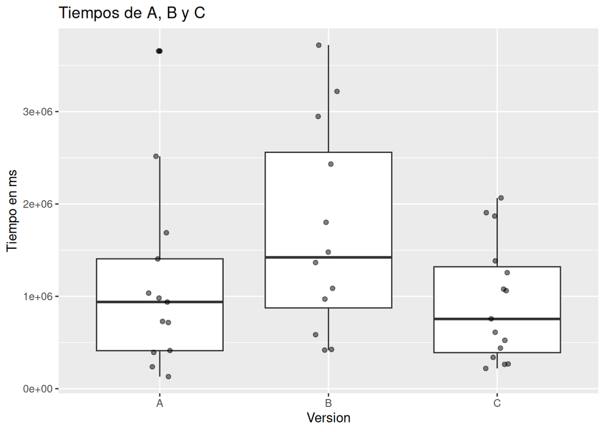

```r
# Boxplot y QQ para revisar las distribuciones
muestra_5 |>
  ggplot(aes(x = version, y = valor)) +
  geom_boxplot() +
  geom_jitter(width = 0.08, alpha = 0.5) +
  labs(title = "Tiempos de A, B y C", x = "Version", y = "Tiempo en ms")
```

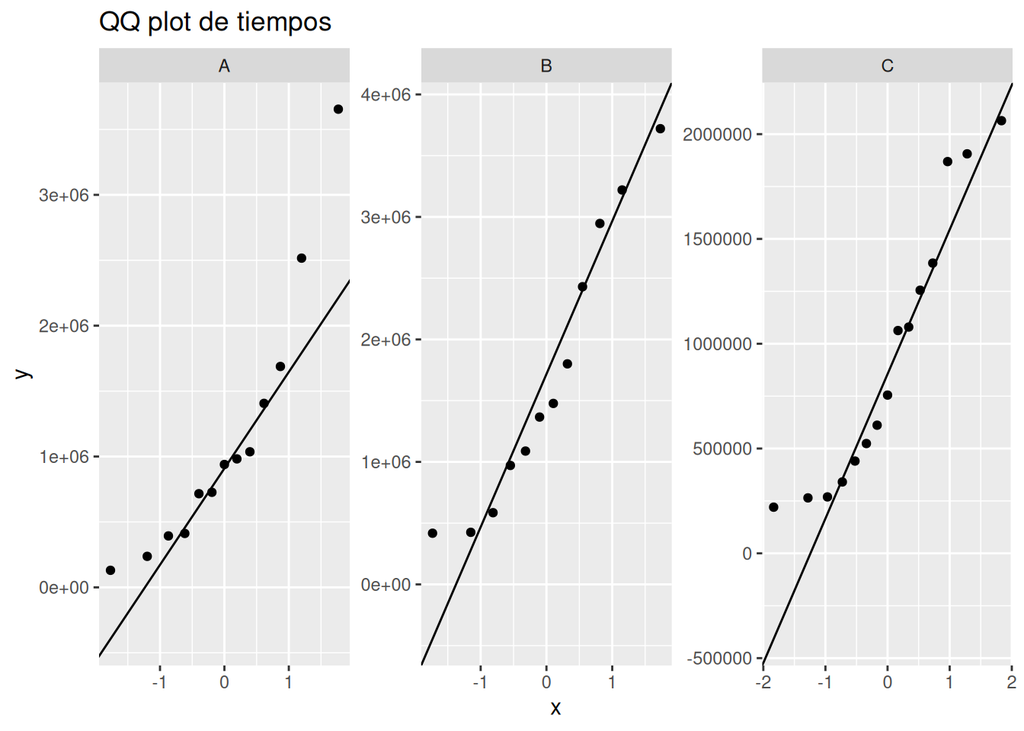

```r
muestra_5 |>
  ggplot(aes(sample = valor)) +
  stat_qq() +
  stat_qq_line() +
  facet_wrap(~ version, scales = "free") +
  labs(title = "QQ plot de tiempos")
```

```r
# Shapiro y Fligner para estudiar las condiciones del ANOVA
normalidad(muestra_5) |>
  knitr::kable(digits = 5)
```

| version | W | p.valor |
| --- | --- | --- |
| A | 0.84568 | 0.02507 |
| B | 0.91731 | 0.26444 |
| C | 0.89473 | 0.07910 |

```r
fligner.test(valor ~ version, data = muestra_5)
```

```
##
##  Fligner-Killeen test of homogeneity of variances
##
## data:  valor by version
## Fligner-Killeen:med chi-squared = 2.0156, df = 2, p-value = 0.365
```

En A Shapiro entrega p menor a 0,05, entonces la condicion de normalidad no esta bien respaldada

Prueba basada en rangos:

Kruskal Wallis, porque son tres grupos indepedientes

H0 = A, B y C tienen la misma distribucion de tiempos

HA = Al menos una distribucion es distinta

En un post hoc de Wilcoxon por pares, H0 seria igualdad de distribuciones para el par y HA seria que son diferentes, con ajuste Holm

```r
# Kruskal Wallis para los tres grupos independientes
prueba_5 <- kruskal.test(valor ~ version, data = muestra_5)

prueba_5
```

```
##
##  Kruskal-Wallis rank sum test
##
## data:  valor by version
## Kruskal-Wallis chi-squared = 3.7142, df = 2, p-value = 0.1561
```

Respuesta:

El p del omnibus es 0.156, mayor a 0,05, por lo que no rechazamos H0 y no corresponde hacer post hoc como conclusion confirmatoria

Aunque en la tabla hay medias distintas, no encontramos evidencia estadistica suficiente para decir que alguna distribucion de tiempos difiera de las otras

## Pregunta 6

“Considerando las instancias con 60 o más nodos, ¿hay diferencias entre los tiempos de ejecución de las versiones A, B y C del algoritmo? Con la semilla 455, saquen 16 instancias para la versión A, 13 instancias para la versión B y 15 instancias para la versión C, todas distintas (muestras independientes). Si sacaron bien la muestra, deberían obtener: A, n = 16 y media 1.110.978; B, n = 13 y media 1.940.876; C, n = 15 y media 1.096.393 [ms].”

Con semilla 455 se sacan 16 instancias para A, 13 para B y 15 para C, todas diferentes

Prueba A Ocupar:

ANOVA de un factor para muestras independientes, ya que no repetimos instancias entre versiones

Con post hoc de comparaciones multiples si el omnibus sale significativo

Hipotesis de la prueba parametrica:

H0 = Los tiempos medios de A, B y C son iguales

HA = Al menos una de las medias es distinta

Condiciones:

1. Escala = El tiempo de ejecucion esta expresado en ms
2. Independencia = No se repiten instancias entre las tres muestras
3. Normalidad = Revisamos las distribuciones de cada version
4. Homogeneidad = Revisamos las varianzas con Fligner

```r
# Pregunta 6: considerando instancias con 60 o mas nodos, hay diferencias entre los tiempos de ejecucion de A, B y C
# Con semilla 455 sacamos 16 instancias para A, 13 para B y 15 para C, todas distintas
# Control: A media 1110978, B media 1940876 y C media 1096393 ms
# Se sortean 44 instancias y luego se reparten por version
base_6 <- datos_xd |>
  filter(n.nodos >= 60)

set.seed(455)
filas_6 <- sample(seq_len(nrow(base_6)), size = 44)

muestra_6 <- bind_rows(
  base_6 |> slice(filas_6[1:16]) |>
    transmute(instancia, version = "A", valor = tiempo.A),
  base_6 |> slice(filas_6[17:29]) |>
    transmute(instancia, version = "B", valor = tiempo.B),
  base_6 |> slice(filas_6[30:44]) |>
    transmute(instancia, version = "C", valor = tiempo.C)
)

# Confirmamos que ninguna instancia quedo repetida
stopifnot(n_distinct(muestra_6$instancia) == 44)

resumen(muestra_6) |>
  knitr::kable(digits = 1)
```

| version | n | media | mediana | desviacion |
| --- | --- | --- | --- | --- |
| A | 16 | 1110978 | 449011 | 1196640.5 |
| B | 13 | 1940876 | 1765646 | 979006.3 |
| C | 15 | 1096393 | 1079583 | 519926.6 |

Las medias esperadas son A = 1.110.978, B = 1.940.876 y C = 1.096.393 ms

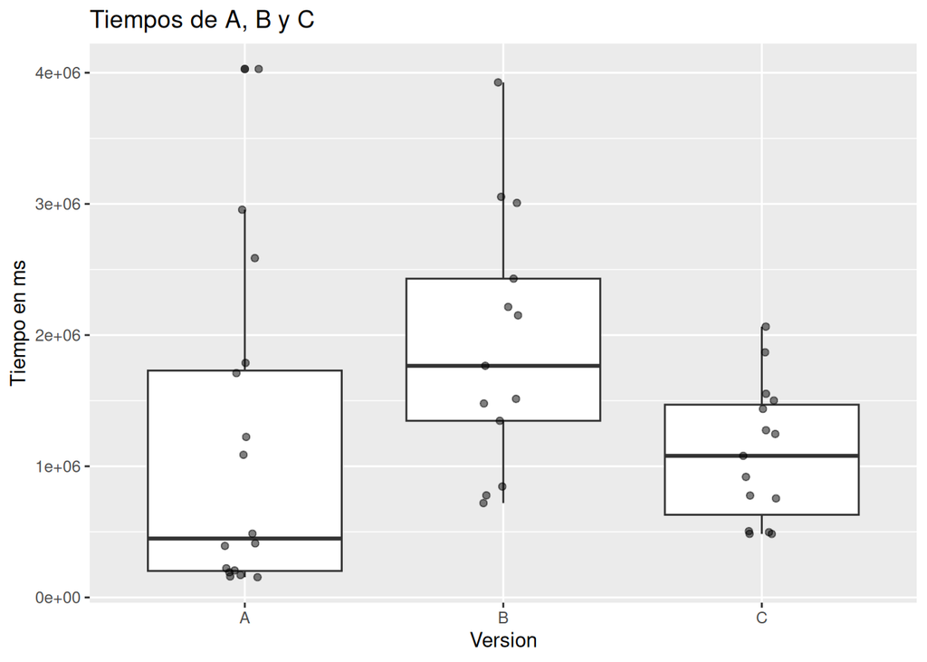

```r
# Distribucion y QQ de los tiempos, separados por version
muestra_6 |>
  ggplot(aes(x = version, y = valor)) +
  geom_boxplot() +
  geom_jitter(width = 0.08, alpha = 0.5) +
  labs(title = "Tiempos de A, B y C", x = "Version", y = "Tiempo en ms")
```

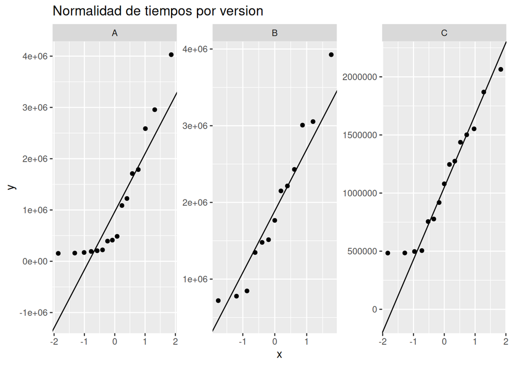

```r
muestra_6 |>
  ggplot(aes(sample = valor)) +
  stat_qq() +
  stat_qq_line() +
  facet_wrap(~ version, scales = "free") +
  labs(title = "Normalidad de tiempos por version")
```

```r
# Miramos la normalidad y dispersion sin correr ANOVA
normalidad(muestra_6) |>
  knitr::kable(digits = 5)
```

| version | W | p.valor |
| --- | --- | --- |
| A | 0.80515 | 0.00319 |
| B | 0.94499 | 0.52463 |
| C | 0.92633 | 0.24036 |

```r
fligner.test(valor ~ version, data = muestra_6)
```

```
##
##  Fligner-Killeen test of homogeneity of variances
##
## data:  valor by version
## Fligner-Killeen:med chi-squared = 2.3354, df = 2, p-value = 0.3111
```

En A la normalidad falla segun Shapiro y tambien hay tiempos extremos, por lo que ANOVA podria ser poco confiable con estos datos

Prueba basada en rangos:

Kruskal Wallis para las tres muestras independientes

H0 = A, B y C tienen la misma distribucion de tiempos

HA = Al menos una version tiene una distribucion distinta

Post hoc = Wilcoxon de suma de rangos para cada par, ajustando los p con Holm

En cada par H0 es igualdad de distribuciones y HA es que no son iguales

```r
# Kruskal Wallis como prueba omnibus
prueba_6 <- kruskal.test(valor ~ version, data = muestra_6)

prueba_6
```

```
##
##  Kruskal-Wallis rank sum test
##
## data:  valor by version
## Kruskal-Wallis chi-squared = 8.1204, df = 2, p-value = 0.01725
```

```r
# Luego comparamos A-B, A-C y B-C con ajuste Holm
pares_6 <- list(c("A", "B"), c("A", "C"), c("B", "C"))

post_6 <- lapply(pares_6, function(par) {
  x <- muestra_6 |>
    filter(version == par[1]) |>
    pull(valor)
  y <- muestra_6 |>
    filter(version == par[2]) |>
    pull(valor)

  tibble(
    comparacion = paste(par, collapse = " vs "),
    p.valor = wilcox.test(x, y, exact = FALSE, correct = FALSE)$p.value
  )
}) |>
  bind_rows() |>
  mutate(p.ajustado = p.adjust(p.valor, method = "holm"))

post_6 |>
  knitr::kable(digits = 5)
```

| comparacion | p.valor | p.ajustado |
| --- | --- | --- |
| A vs B | 0.02259 | 0.04517 |
| A vs C | 0.22043 | 0.22043 |
| B vs C | 0.01205 | 0.03616 |

Respuesta:

El p de Kruskal Wallis es 0.0172, menor a 0,05, por lo que rechazamos H0 y encontramos evidencia de diferencias entre las versiones

En el post hoc corregido por Holm, B difiere de A y de C, pero A y C no muestran una diferencia significativa

B tiende a tardar mas segun los tiempos de la muesra, mientras que A y C no se diferencian significativamente con este analisis

# Avance 2

## Version de R

```r
# Version de R usada al ejecutar el analisis
R.version.string
```

```
## [1] "R version 4.6.2 (2026-10-29)"
```

## Pregunta 2 (Método no paramétrico: Prueba de Friedman)

Viendo que se evalúan 3 versiones de algoritmo (k = 3) enlas mismas 21 instancias (muestras correlacionadas) y la normalidad de las diferencias por pares no se cumple satisfactoriamente, se aplica la prueba de Friedman junto con el tamaño del efecto W de Kendall y un procedimiento post hoc mediante pruebas de rangos con signo de Wilcoxon pareadas con ajuste de Holm y análisis de sensibilidad con Benjamini-Hochberg.

Hipótesis:

H0: dentro de cada instancia, las tres versiones (A, B y C) son intercambiables; ninguna tiende a entregar porcentajes del óptimo mayores que otra.

HA: dentro de las mismas instancias, al menos una versión tiende a entregar porcentajes del óptimo mayores o menores que alguna otra.

```r
# Preparar los datos en formato largo asegurando factores y orden por instancia
datos_fri_2 <- muestra_2 |>
  dplyr::select(instancia, mejor.A, mejor.B, mejor.C) |>
  pivot_longer(
    cols = starts_with("mejor."),
    names_to = "Version",
    values_to = "Calidad"
  ) |>
  mutate(
    Instancia = factor(instancia),
    Version = factor(sub("mejor.", "", Version, fixed = TRUE), levels = c("A", "B", "C"))
  ) |>
  arrange(Version, Instancia)

alfa_2 <- 0.05

# Aplicar la prueba de Friedman y calcular el tamaño del efecto (W de Kendall)
prueba_fri_2 <- datos_fri_2 |>
  friedman_test(Calidad ~ Version | Instancia) |>
  mutate(across(c(statistic, p), ~ num(., digits = 3)))

cat("Prueba de Friedman\n")
```

```
## Prueba de Friedman
```

```r
print(prueba_fri_2)
```

```
## # A tibble: 1 × 6
##   .y.         n statistic    df         p method
##   <chr>   <int> <num:.3!> <dbl> <num:.3!> <chr>
## 1 Calidad    21     9.238     2     0.010 Friedman test
```

```r
efecto_fri_2 <- datos_fri_2 |>
  friedman_effsize(Calidad ~ Version | Instancia) |> mutate(effsize = num(effsize, digits = 3))

cat("\nTamaño del efecto\n")
```

```
##
## Tamaño del efecto
```

```r
print(efecto_fri_2)
```

```
## # A tibble: 1 × 5
##   .y.         n   effsize method    magnitude
##   <chr>   <int> <num:.3!> <chr>     <ord>
## 1 Calidad    21     0.220 Kendall W small
```

```r
# Procedimiento post hoc: pruebas de rangos con signo de Wilcoxon por pares
# ajustando con Holm y con Benjamini y Hochberg (Script 10.21)
pares_fri_2 <- datos_fri_2 |>
  pairwise_wilcox_test(Calidad ~ Version, paired = TRUE, p.adjust.method = "holm") |>
  mutate(p.BH = p.adjust(p, method = "BH")) |>
  dplyr::select(group1, group2, n1, statistic, p, p.Holm = p.adj, p.BH) |>
  mutate(across(c(p, p.Holm, p.BH), ~ num(., digits = 4)))

cat("\nPruebas de rangos con signo por pares\n")
```

```
##
## Pruebas de rangos con signo por pares
```

```r
print(pares_fri_2, width = Inf)
```

```
## # A tibble: 3 × 7
##   group1 group2    n1 statistic         p    p.Holm      p.BH
##   <chr>  <chr>  <int>     <dbl> <num:.4!> <num:.4!> <num:.4!>
## 1 A      B         21     197      0.0033    0.0098    0.0098
## 2 A      C         21     182.     0.0199    0.0399    0.0299
## 3 B      C         21      77.5    0.1937    0.1937    0.1937
```

Conclusión: Con un nivel de significación $\alpha = 0,05$, la prueba ómnibus de Friedman rechaza la hipótesis nula ($p < 0,05$), indicando que dentro de las mismas instancias al menos una versión del algoritmo tiende a obtener soluciones más cercanas al óptimo que otra. El procedimiento post hoc (tanto con el ajuste de Holm como con el de Benjamini y Hochberg) muestra diferencias estadísticamente significativas entre la versión A y la versión B, y entre la versión A y la versión C, mientras que entre B y C no hay evidencia suficiente de diferencia. En consecuencia, la versión A tiende a encontrar soluciones de mayor calidad que las versiones B y C al resolver las mismas instancias.

## Pregunta 3 (Método no paramétrico: Prueba de suma de rangos de Wilcoxon)

Para comparar los tiempos de ejecución de las versiones B= 24 y C=23 en muestras independientes donde se incumple la normalidad (en B) y la homogeneidad de varianzas (Fligner y Killeen p < 0,05), se aplica la prueba de suma de rangos de Wilcoxon y se calcula su tamaño del efecto r.

Hipótesis:

H0: los tiempos de ejecución de las versiones B y C tienen la misma distribución.

HA: los tiempos de ejecución de una de las versiones tienden a ser mayores que los de la otra.

```r
# Preparar matriz de datos con factor ordenado (Script 10.13 y 10.14)
datos_int_3 <- muestra_3 |>
  mutate(
    Version = factor(version, levels = c("B", "C")),
    Tiempo = valor
  )

alfa_3 <- 0.05

# Aplicar la prueba de suma de rangos de Wilcoxon
prueba_w_3 <- datos_int_3 |>
  wilcox_test(Tiempo ~ Version, alternative = "two.sided",
              detailed = TRUE, conf.level = 1 - alfa_3) |>
  dplyr::select(group1, group2, n1, n2, statistic, p,
                estimate, conf.low, conf.high) |>
  mutate(across(c(p, estimate, conf.low, conf.high), ~ num(., digits = 3)))

cat("Prueba de suma de rangos de Wilcoxon\n")
```

```
## Prueba de suma de rangos de Wilcoxon
```

```r
print(prueba_w_3, width = Inf)
```

```
## # A tibble: 1 × 9
##   group1 group2    n1    n2 statistic         p   estimate   conf.low
##   <chr>  <chr>  <int> <int>     <dbl> <num:.3!>  <num:.3!>  <num:.3!>
## 1 B      C         24    23       418     0.002 636839.500 204328.000
##     conf.high
##     <num:.3!>
## 1 1338880.000
```

```r
# Calcular el tamaño del efecto
efecto_w_3 <- datos_int_3 |>
  wilcox_effsize(Tiempo ~ Version) |>
  mutate(effsize = num(effsize, digits = 3))

cat("\nTamaño del efecto\n")
```

```
##
## Tamaño del efecto
```

```r
print(efecto_w_3)
```

```
## # A tibble: 1 × 7
##   .y.    group1 group2   effsize    n1    n2 magnitude
##   <chr>  <chr>  <chr>  <num:.3!> <int> <int> <ord>
## 1 Tiempo B      C          0.441    24    23 moderate
```

Conclusión: Con un nivel de significación $\alpha = 0,05$, se rechaza la hipótesis nula (p < 0,05), por lo que existe evidencia suficiente para afirmar que los tiempos de ejecución de B tienden a ser mayores que C. Como la prueba de Fligner y Killeen vista en el Avance 1 muestra evidencia de que las dispersiones difieren entre ambos grupos, esta conclusión se interpreta en términos de dominancia estocástica (los tiempos de B tienden a superar a los de C) y la estimación de Hodges y Lehmann (estimate) no debe leerse directamente como la diferencia entre las medianas poblacionales.

## Pregunta 4 (Método paramétrico con transformación de datos)

Para comparar tiempos de ejecución de las versiones A=16 y B=17 en muestras independientes donde la muestra A presenta asimetría y no cumple la condición de normalidad en la escala original, se aplica una transformación de Box-Cox estimando un único parámetro $\lambda$ conjunto a partir del modelo lineal Tiempo / Version.

```r
# Preparar datos para la transformación (Script 10.9 y 10.10)
datos_tr_4 <- muestra_4 |>
  mutate(
    Version = factor(version, levels = c("A", "B")),
    Tiempo = valor
  )

# Estimar un solo lambda de Box-Cox para los dos grupos independientes
bc_4 <- powerTransform(lm(Tiempo ~ Version, data = datos_tr_4))
print(round(summary(bc_4)[["result"]], 3))
```

```
##    Est Power Rounded Pwr Wald Lwr Bnd Wald Upr Bnd
## Y1     0.261           0       -0.125        0.646
```

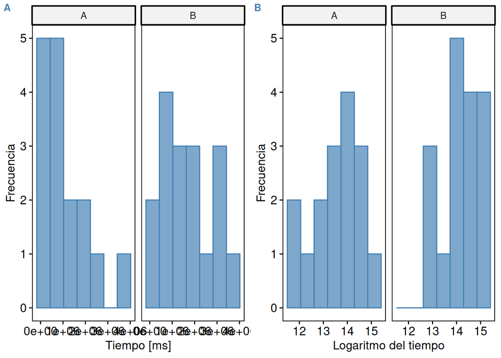

```r
# Extraer límites del intervalo de 95% de confianza de Wald para decidir la transformación
res_bc_4 <- summary(bc_4)[["result"]]
lwr_4 <- res_bc_4[1, "Wald Lwr Bnd"]
upr_4 <- res_bc_4[1, "Wald Upr Bnd"]
lambda_est_4 <- bc_4[["lambda"]]

# Siguiendo lo visto en la lecrura de Box Cox: si el IC de 95% contiene al 0, se prefiere la
# transformación logarítmica (Rounded Pwr = 0) porque dejaria llevar la diferencia
# de vuelta a escala original como razón de medias geométricas. Sino,se usa bcPower con el lambda estimado.
usa_log_4 <- (lwr_4 <= 0 && upr_4 >= 0)

if (usa_log_4) {
  datos_tr_4 <- datos_tr_4 |> mutate(Tiempo_tr = log(Tiempo))
  etiqueta_tr_4 <- "Logaritmo del tiempo"
} else {
  datos_tr_4 <- datos_tr_4 |> mutate(Tiempo_tr = bcPower(Tiempo, lambda_est_4))
  etiqueta_tr_4 <- paste0("Tiempo transformado (Box-Cox, lambda = ", round(lambda_est_4, 3), ")")
}

# Graficar las distribuciones antes y después de la transformación (Script 10.9)
h_orig_4 <- gghistogram(datos_tr_4, x = "Tiempo", bins = 7, facet.by = "Version",
                        color = "steelblue", fill = "steelblue", alpha = 0.7,
                        xlab = "Tiempo [ms]", ylab = "Frecuencia")

h_tr_4 <- gghistogram(datos_tr_4, x = "Tiempo_tr", bins = 7, facet.by = "Version",
                      color = "steelblue", fill = "steelblue", alpha = 0.7,
                      xlab = etiqueta_tr_4, ylab = "Frecuencia")

plot_4 <- ggarrange(h_orig_4, h_tr_4, ncol = 2, nrow = 1, labels = "AUTO",
                    font.label = list(size = 10, color = "steelblue"))
print(plot_4)
```

```r
# Revisar la normalidad de cada grupo y la igualdad de varianzas en la escala transformada
normalidad_tr_4 <- datos_tr_4 |>
  group_by(Version) |>
  shapiro_test(Tiempo_tr) |>
  mutate(across(c(statistic, p), ~ num(., digits = 3)))

cat("\nPrueba de Shapiro-Wilk en cada grupo (datos transformados)\n")
```

```
##
## Prueba de Shapiro-Wilk en cada grupo (datos transformados)
```

```r
print(normalidad_tr_4)
```

```
## # A tibble: 2 × 4
##   Version variable  statistic         p
##   <fct>   <chr>     <num:.3!> <num:.3!>
## 1 A       Tiempo_tr     0.968     0.798
## 2 B       Tiempo_tr     0.932     0.240
```

```r
levene_tr_4 <- datos_tr_4 |>
  levene_test(Tiempo_tr ~ Version) |>
  mutate(across(c(statistic, p), ~ num(., digits = 3)))

cat("\nPrueba de Levene (datos transformados)\n")
```

```
##
## Prueba de Levene (datos transformados)
```

```r
print(levene_tr_4)
```

```
## # A tibble: 1 × 4
##     df1   df2 statistic         p
##   <int> <int> <num:.3!> <num:.3!>
## 1     1    31     0.556     0.462
```

Hipótesis en la escala transformada:

H0: las medias de los tiempos transformados de las versiones A y B son iguales ($\mu_{A}^{\prime} = \mu_{B}^{\prime}$), lo que en el caso logarítmico equivale a que la razón entre las medias geométricas en la escala original es igual a 1.

HA: las medias de los tiempos transformados de las versiones A y B son distintas ($\mu_{A}^{\prime} \neq \mu_{B}^{\prime}$).

```r
# Aplicar la prueba t para muestras independientes en la escala transformada (Script 10.11)
var_iguales_4 <- levene_tr_4$p >= 0.05

if (usa_log_4) {
  prueba_tr_4 <- datos_tr_4 |>
    t_test(Tiempo_tr ~ Version, var.equal = var_iguales_4, detailed = TRUE) |>
    mutate(
      razon = exp(estimate),
      razon_inf = exp(conf.low),
      razon_sup = exp(conf.high)
    ) |>
    dplyr::select(statistic, df, p, razon, razon_inf, razon_sup) |>
    mutate(across(c(statistic, razon, razon_inf, razon_sup), ~ num(., digits = 3)))
} else {
  prueba_tr_4 <- datos_tr_4 |>
    t_test(Tiempo_tr ~ Version, var.equal = var_iguales_4, detailed = TRUE) |>
    dplyr::select(statistic, df, p, estimate, conf.low, conf.high) |>
    mutate(across(c(statistic, estimate, conf.low, conf.high), ~ num(., digits = 3)))
}

cat("\nPrueba t para muestras independientes (datos transformados)\n")
```

```
##
## Prueba t para muestras independientes (datos transformados)
```

```r
print(prueba_tr_4)
```

```
## # A tibble: 1 × 6
##   statistic    df      p     razon razon_inf razon_sup
##   <num:.3!> <dbl>  <dbl> <num:.3!> <num:.3!> <num:.3!>
## 1    -1.997    31 0.0546     0.556     0.305     1.012
```

Conclusión: Tras aplicar transformación sugerida por el método de Box-Cox, la prueba de Shapiro-Wilk en cada grupo no muestra evidencia en contra de la normalidad ($p > 0,05$) y la prueba de Levene respalda la homogeneidad de varianzas en la escala transformada. Al contrastar ambos grupos mediante la prueba t de Student para muestras independientes sobre los datos transformados con un nivel de significación $\alpha = 0,05$, se obtiene un valor $p = 0.0546$. Como $p > 0,05$, no se rechaza la hipótesis nula: no existe evidencia estadística suficiente para afirmar que los tiempos de ejecución de las versiones A y B difieran (ni en sus medias en la escala transformada, ni en sus medias geométricas o medianas en la escala original de milisegundos).